title: “Project Write Up” output: html_document date: “03/03/26” —

```r
library(tidyverse)
setwd("C:/Users/dmd23/OneDrive - University of the Pacific")
drugs <- read_csv("drug_consumption.csv")
```

```r
CL_cols <- c("amphet", "caff", "coke", "shrooms", "alochol", "amyl", "benzos", "cannabis", "choc", "crack", "ecstasy", "heroin", "ketamine", "legalh", "lsd", "meth", "nicotine", "semer", "vsa")
drugs[CL_cols] <- lapply(drugs[CL_cols], function(x) as.integer(sub("^CL", "", x)))
map <- c("0.48246" = "Female", "-0.48246" = "Male")
drugs$gender <- map[as.character(drugs$gender)]
```

Link to the dataset: https://archive.ics.uci.edu/dataset/373/drug+consumption+quantified

Description: this dataset seeks to quantify drug consumption and to find a correlation as well to personality - each participant is asked to take a test that scores them on personality traits such as neuroticism, extraversion, openness to new experience, etc. Then, each participant was also asked about their usage of every prevalent drug, from drugs as minor as caffeine and chocolate to crack, heroin and ecstasy. Usage of drugs were rated on a scale of 0-6, with 6 being “used [drug] in the last day” and 0 being “never used”.

Our motivation: We used this data as well as their means to evaluate any relationship between personality traits and drug usage. Given the growing increase of hard drug usage across the world, we are hoping to answer the question of whether or not drug usage isn’t just a choice but something that is predetermined by the people that we are and the personalities that we have.

Below are some basic summary statistics of our dataset:

```r
summary(drugs)
```

```
##        id              age              gender               educ
##  Min.   :   1.0   Min.   :-0.95197   Length:1885        Min.   :-2.435910
##  1st Qu.: 474.0   1st Qu.:-0.95197   Class :character   1st Qu.:-0.611130
##  Median : 946.0   Median :-0.07854   Mode  :character   Median :-0.059210
##  Mean   : 945.3   Mean   : 0.03461                      Mean   :-0.003806
##  3rd Qu.:1417.0   3rd Qu.: 0.49788                      3rd Qu.: 0.454680
##  Max.   :1888.0   Max.   : 2.59171                      Max.   : 1.984370
##     country          ethnicity           nscore               escore
##  Min.   :-0.5701   Min.   :-1.1070   Min.   :-3.4643600   Min.   :-3.2739300
##  1st Qu.:-0.5701   1st Qu.:-0.3169   1st Qu.:-0.6782500   1st Qu.:-0.6950900
##  Median : 0.9608   Median :-0.3169   Median : 0.0425700   Median : 0.0033200
##  Mean   : 0.3555   Mean   :-0.3096   Mean   : 0.0000466   Mean   :-0.0001628
##  3rd Qu.: 0.9608   3rd Qu.:-0.3169   3rd Qu.: 0.6296700   3rd Qu.: 0.6377900
##  Max.   : 0.9608   Max.   : 1.9072   Max.   : 3.2739300   Max.   : 3.2739300
##      oscore               ascore              cscore
##  Min.   :-3.2739300   Min.   :-3.464360   Min.   :-3.4643600
##  1st Qu.:-0.7172700   1st Qu.:-0.606330   1st Qu.:-0.6525300
##  Median :-0.0192800   Median :-0.017290   Median :-0.0066500
##  Mean   :-0.0005344   Mean   :-0.000245   Mean   :-0.0003861
##  3rd Qu.: 0.7233000   3rd Qu.: 0.760960   3rd Qu.: 0.5848900
##  Max.   : 2.9016100   Max.   : 3.464360   Max.   : 3.4643600
##    impulsive               ss               alochol          amphet
##  Min.   :-2.555240   Min.   :-2.078480   Min.   :0.000   Min.   :0.000
##  1st Qu.:-0.711260   1st Qu.:-0.525930   1st Qu.:4.000   1st Qu.:0.000
##  Median :-0.217120   Median : 0.079870   Median :5.000   Median :0.000
##  Mean   : 0.007216   Mean   :-0.003292   Mean   :4.635   Mean   :1.341
##  3rd Qu.: 0.529750   3rd Qu.: 0.765400   3rd Qu.:6.000   3rd Qu.:2.000
##  Max.   : 2.901610   Max.   : 1.921730   Max.   :6.000   Max.   :6.000
##       amyl            benzos           caff          cannabis
##  Min.   :0.0000   Min.   :0.000   Min.   :0.000   Min.   :0.000
##  1st Qu.:0.0000   1st Qu.:0.000   1st Qu.:5.000   1st Qu.:1.000
##  Median :0.0000   Median :0.000   Median :6.000   Median :3.000
##  Mean   :0.6069   Mean   :1.465   Mean   :5.484   Mean   :2.989
##  3rd Qu.:1.0000   3rd Qu.:3.000   3rd Qu.:6.000   3rd Qu.:5.000
##  Max.   :6.0000   Max.   :6.000   Max.   :6.000   Max.   :6.000
##       choc            coke           crack           ecstasy
##  Min.   :0.000   Min.   :0.000   Min.   :0.0000   Min.   :0.000
##  1st Qu.:5.000   1st Qu.:0.000   1st Qu.:0.0000   1st Qu.:0.000
##  Median :5.000   Median :0.000   Median :0.0000   Median :0.000
##  Mean   :5.107   Mean   :1.161   Mean   :0.2976   Mean   :1.314
```

[output cut: 8 more lines]

```
##  Max.   :6.000   Max.   :6.0000   Max.   :6.000   Max.   :6.000
##       meth           shrooms         nicotine         semer
##  Min.   :0.0000   Min.   :0.000   Min.   :0.000   Min.   :0.000000
##  1st Qu.:0.0000   1st Qu.:0.000   1st Qu.:1.000   1st Qu.:0.000000
##  Median :0.0000   Median :0.000   Median :3.000   Median :0.000000
##  Mean   :0.8265   Mean   :1.187   Mean   :3.201   Mean   :0.009549
##  3rd Qu.:0.0000   3rd Qu.:2.000   3rd Qu.:6.000   3rd Qu.:0.000000
##  Max.   :6.0000   Max.   :6.000   Max.   :6.000   Max.   :4.000000
##       vsa
##  Min.   :0.0000
##  1st Qu.:0.0000
##  Median :0.0000
##  Mean   :0.4334
##  3rd Qu.:0.0000
##  Max.   :6.0000
```

Visualizations:

Plot showing relationship between two quantitative variables, extraversion and agreeableness:

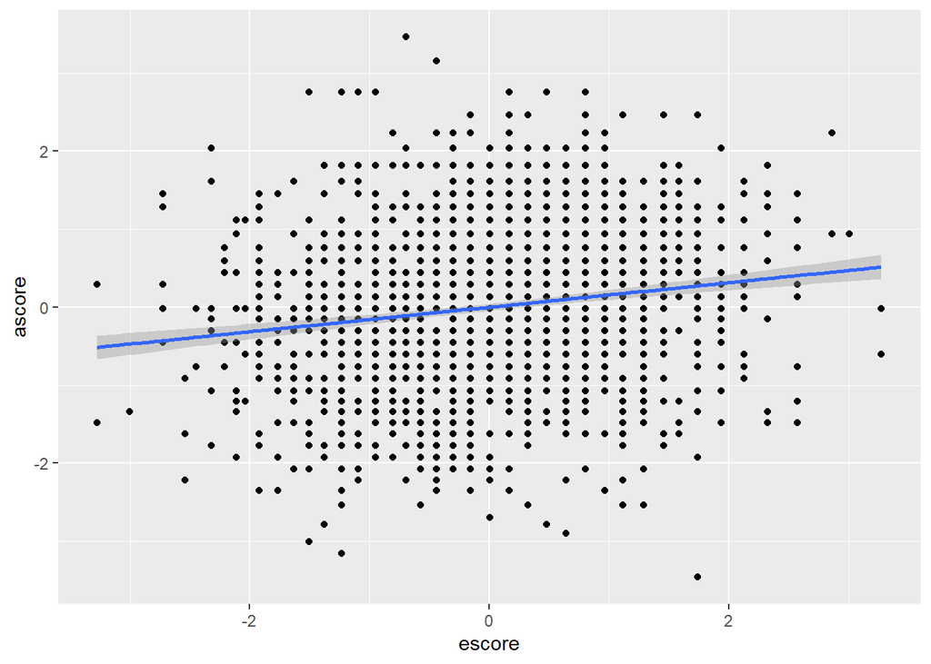

```r
ggplot(drugs, aes(escore, ascore)) + geom_point() + geom_smooth(method = "lm")
```

From this plot, it’s evident that there’s a slightly positive correlation between agreeableness and extraversion, but overall there’s a lot of variance from the line of best fit so there’s not a strong correlation between the two.

Plot showing relationship between categorical and quantitative variable, extraversion and caffeine consumption:

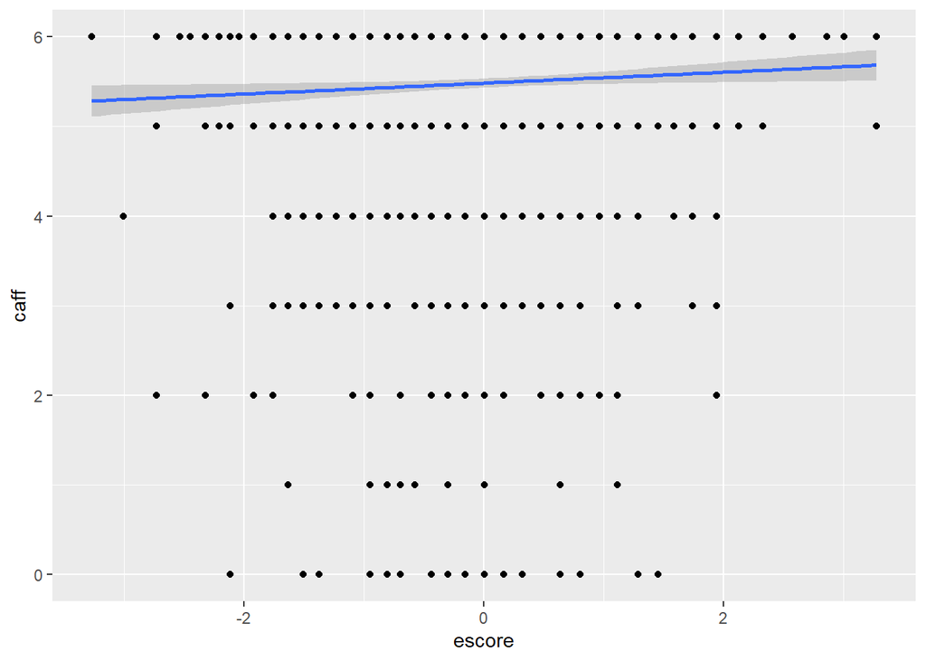

```r
ggplot(drugs, aes(escore, caff)) + geom_point() + geom_smooth(method = 'lm')
```

From interpreting this plot, it’s evident that someone’s caffeine consumption and their extraversion are not in correlation, as the line of best fit is rather flat, and the extraversion scores are spread out throughout all caffeine values. This is surprising given the concept that caffeine generally makes us more hyper and active, which we hoped would correlate to more extraversion.

From our project, we know that mushroom and LSD usage have the highest correlation of any pair of drugs, and the personality scores that has the highest correlation with these two is extraversion and impulsive sensation seeking - thus an interesting plot would be mushroom and LSD usage with the coloring by escore and the size scaled by ss:

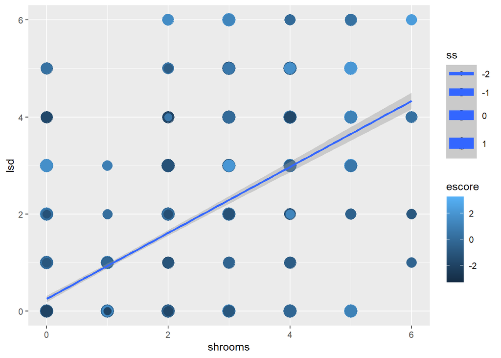

```r
ggplot(drugs, aes(shrooms, lsd, color = escore, size = ss)) + geom_point() + geom_smooth(method = 'lm')
```

One noticeable feature of this graph is how the color (based on escore) is more prevalent in the upper right corner of the graph which can be evidence of a correlation between escore and mushroom and LSD usage. In terms of the sizing of the dots, there isn’t anything evident that can show a correlation between impulsive sensation seeking score and usage of these drugs.

Dataset manipulations:

```r
drugs %>%
  group_by(gender) %>%
  filter(ss > 1) %>%
  summarize(avg_cannabis = mean(cannabis))
```

```
## # A tibble: 2 × 2
##   gender avg_cannabis
##   <chr>         <dbl>
## 1 Female         3.99
## 2 Male           4.61
```

This manipulation shows that on average, women with an impulsive sensation seeking score higher than 1 (ImpSS for this dataset ranges from -2 to 2, with a higher score indicating a person who’s more likely to act impulsively, seek thrills, take risks, etc.) consume less cannabis than men by 13%. This was performed by grouping the dataset into their gender, filtering out the participants with an ss less than or equal to 1 and then finding the mean cannabis usage for the remaining participants

Statistical Analyses:

A correlation between two quantitative variables in dataset:

```r
cor.test(drugs$lsd, drugs$shrooms)
```

```
##
##  Pearson's product-moment correlation
##
## data:  drugs$lsd and drugs$shrooms
## t = 39.019, df = 1883, p-value < 2.2e-16
## alternative hypothesis: true correlation is not equal to 0
## 95 percent confidence interval:
##  0.6428860 0.6928601
## sample estimates:
##       cor
## 0.6686274
```

```r
cor.test(drugs$lsd, drugs$shrooms, method = 'spearman')
```

```
##
##  Spearman's rank correlation rho
##
## data:  drugs$lsd and drugs$shrooms
## S = 363789202, p-value < 2.2e-16
## alternative hypothesis: true rho is not equal to 0
## sample estimates:
##       rho
## 0.6741129
```

The interpretation of the correlation betweeen mushrooms and LSD usage shows a somewhat strong correlation between the two drugs and their usages with a Pearson correlation coefficient of 0.6686274 and a Spearman correlation of 0.6741129, and given a low p-value there’s indication of statistical significance for the relationship between these two variables

```r
lm(ss ~ coke, data = drugs)
```

```
##
## Call:
## lm(formula = ss ~ coke, data = drugs)
##
## Coefficients:
## (Intercept)         coke
##     -0.2573       0.2187
```

The linear regression model of ImpSS and cocaine usage indicates that generally, a person that does not consume cocaine likely has an ImpSS score of -0.2573 - additionally, the slope of the linear regression shows that as the amount of cocaine usage increases, there’s additionally an increase in the ImpSS score, which makes sense given the nature of what ImpSS measures and the effects of cocaine usage.

T-test performed:

```r
t.test(nicotine ~ gender, data = drugs)
```

```
##
##  Welch Two Sample t-test
##
## data:  nicotine by gender
## t = -8.4932, df = 1881.2, p-value < 2.2e-16
## alternative hypothesis: true difference in means between group Female and group Male is not equal to 0
## 95 percent confidence interval:
##  -1.1411933 -0.7130236
## sample estimates:
## mean in group Female   mean in group Male
##             2.736730             3.663839
```

Given the results of the t-test between gender and nicotine usage, it’s evident that males consume nicotine more than women, as the difference between the two means is around 1, with the means being at ~4 for men and ~3 for women, which is the difference between using nicotine in the last month vs the using nicotine in the last year.

Overarching conclusion: The notion that personality and certain personality scores affect a person’s drug usage is selectively true - there’s evidence between certain drugs and personality traits that show some significant positive correlation, while many others, specifically the less common drugs, show no correlation. An additional factor was gender, which plays a factor in personalities and drug consumption, and which also yielded statistical relevance when performing t tests and data manipulation to see differences in consumptions between males and females. Overall, the hypothesis that personalities of people directly affects drug usage is not true for certain drugs (nicotine, caffeine, etc.) and untrue for others (meth, ketamine, etc.)